# STA309Final_All

Juyuan Li

2023-05-11

```r
library(tidyverse)
library(caret)
library(randomForest)

# Input the data
data <- read.csv("heart_disease.csv")

# Data cleaning
data$FastingBS <- as.factor(data$FastingBS)
data$HeartDisease <- as.factor(data$HeartDisease)
```

```r
# Using the caret package, setup a 5-fold cross validation study that is repeated 10 times.
control <- trainControl(method = "repeatedcv", number = 5, repeats = 10)

# Logistic regression model (glm)
set.seed(1000)
logistic_model <- train(HeartDisease ~ ., data = data, method = "glm", trControl = control)

# Random Forest model (rf), search over all mtry values from 1 to 6
set.seed(1000)
rf_model <- train(HeartDisease ~ ., data = data, method = "rf", trControl = control,
                  tuneGrid=expand.grid(mtry=1:6),importance=TRUE)

# Compare and contrast the distribution of predictive Accuracy
models_resamples <- resamples(list(logistic = logistic_model, rf = rf_model))
summary(models_resamples)
```

```
##
## Call:
## summary.resamples(object = models_resamples)
##
## Models: logistic, rf
## Number of resamples: 50
##
## Accuracy
##               Min.   1st Qu.    Median      Mean   3rd Qu.      Max. NA's
## logistic 0.8306011 0.8478261 0.8637592 0.8624115 0.8750000 0.9130435    0
## rf       0.8415301 0.8641304 0.8750000 0.8754853 0.8857136 0.9184783    0
##
## Kappa
##               Min.   1st Qu.    Median      Mean   3rd Qu.      Max. NA's
## logistic 0.6563276 0.6897402 0.7234335 0.7206023 0.7462501 0.8235858    0
## rf       0.6790955 0.7233890 0.7446637 0.7465155 0.7674564 0.8344132    0
```

```r
# Find using how many randomly selected predictor variables for each split is the best approach
print(rf_model)
```

```
## Random Forest
##
## 918 samples
##  11 predictor
##   2 classes: '0', '1'
##
## No pre-processing
## Resampling: Cross-Validated (5 fold, repeated 10 times)
## Summary of sample sizes: 734, 735, 734, 734, 735, 734, ...
## Resampling results across tuning parameters:
##
##   mtry  Accuracy   Kappa
##   1     0.8680767  0.7306850
##   2     0.8754853  0.7465155
##   3     0.8753772  0.7464969
##   4     0.8710175  0.7377139
##   5     0.8697072  0.7350879
##   6     0.8688388  0.7333626
##
## Accuracy was used to select the optimal model using the largest value.
## The final value used for the model was mtry = 2.
```

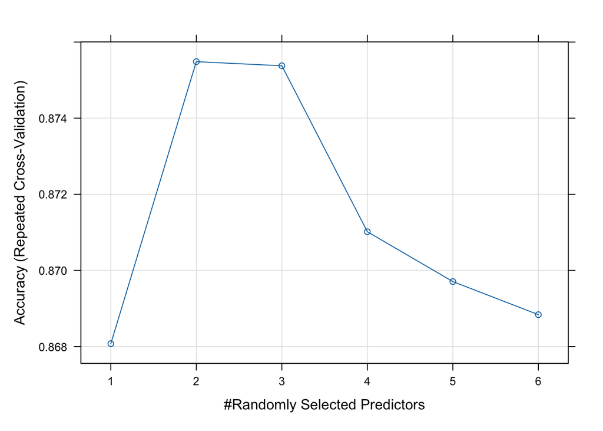

```r
plot(rf_model)
```

```r
# Obtain the importance of each variable
varImp(rf_model$finalModel)
```

```
##                          0         1
## Age               8.015065  8.015065
## SexM             16.474281 16.474281
## ChestPainTypeATA 13.739364 13.739364
## ChestPainTypeNAP 11.312178 11.312178
## ChestPainTypeTA   3.398701  3.398701
## RestingBP         3.612911  3.612911
## Cholesterol      15.459420 15.459420
## FastingBS1       11.762094 11.762094
## RestingECGNormal  4.487822  4.487822
## RestingECGST      1.974925  1.974925
## MaxHR            11.833626 11.833626
## ExerciseAnginaY  17.950264 17.950264
## Oldpeak          16.130702 16.130702
## ST_SlopeFlat     19.315449 19.315449
## ST_SlopeUp       21.616619 21.616619
```

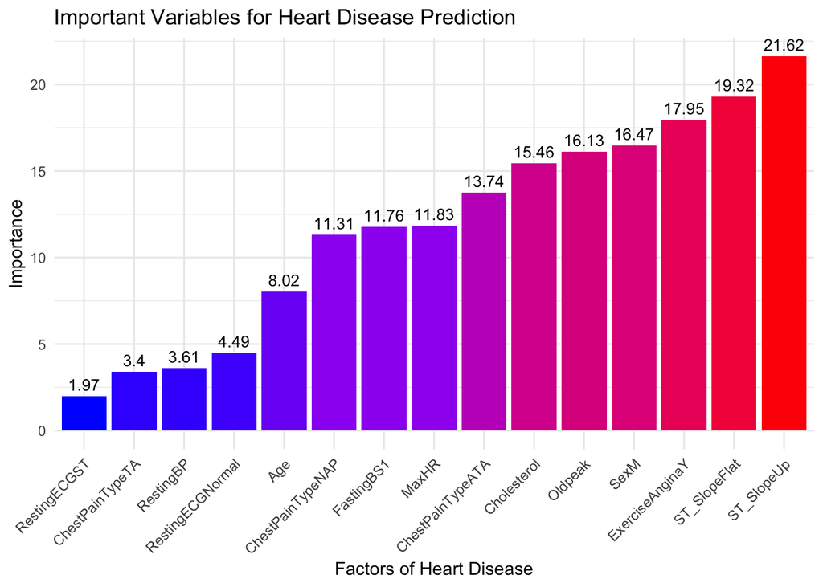

```r
var_importance <- data.frame(
  Variable = c("Age", "SexM", "ChestPainTypeATA", "ChestPainTypeNAP", "ChestPainTypeTA", "RestingBP", "Cholesterol", "FastingBS1", "RestingECGNormal", "RestingECGST", "MaxHR", "ExerciseAnginaY", "Oldpeak", "ST_SlopeFlat", "ST_SlopeUp"),
  Importance = c(8.015065, 16.474281, 13.739364, 11.312178, 3.398701, 3.612911, 15.459420, 11.762094, 4.487822, 1.974925, 11.833626, 17.950264, 16.130702, 19.315449, 21.616619)
)

# Load ggplot2 for plotting
library(ggplot2)

# Create a bar chart of important variables
important_variables_plot <- ggplot(var_importance, aes(x = reorder(Variable, Importance), y = Importance, fill = Importance)) +
  geom_bar(stat = "identity") +
  scale_fill_gradient2(low = "blue", mid = "purple", high = "red", midpoint = median(var_importance$Importance), guide = FALSE) +
  theme_minimal() +
  theme(axis.text.x = element_text(angle = 45, hjust = 1)) +
  xlab("Factors of Heart Disease") +
  ylab("Importance") +
  ggtitle("Important Variables for Heart Disease Prediction") +
  geom_text(aes(label = round(Importance, 2)), vjust = -0.5, size = 3.5)

# Show the plot
important_variables_plot
```

**According to the all the result, Random Forest model has better accuracy by about 1-2% than the Logistic regression model(Median 0.863 and 0.875; Mean 0.862 and 0.875). Heart disease is a leading cause of death globally, and early detection and intervention play a crucial role in improving patient outcomes. In the context of heart disease prediction, even a 1-2% improvement in model accuracy can potentially save lives, as it translates to identifying more individuals at risk and enabling timely interventions. Considering the large number of patients screened for heart disease risk, a 1-2% increase in prediction accuracy can lead to a significant number of individuals being correctly identified as high-risk. These individuals can then benefit from preventive measures, such as lifestyle changes, regular check-ups, and medication, ultimately reducing their risk of developing heart disease or experiencing severe complications. In conclusion, while the performance difference between the two models might seem small at first glance, it is important to recognize the real-world implications of such improvements in predictive accuracy, especially when dealing with life-threatening conditions like heart disease.**

**Based on the random forest model, ST segment slopes (ST_SlopeUp and ST_SlopeFlat) on an ECG are important indicators of potential heart disease, as they can signal ischemia or other heart abnormalities. Exercise-induced angina is another strong predictor, as it suggests that the heart may not be receiving enough oxygen during physical activity. Gender, specifically male, has been found to be a risk factor for heart disease. Lastly, high cholesterol levels are known to contribute to the development of heart disease, as they can lead to the formation of plaque in the arteries, narrowing the blood vessels and restricting blood flow to the heart.**

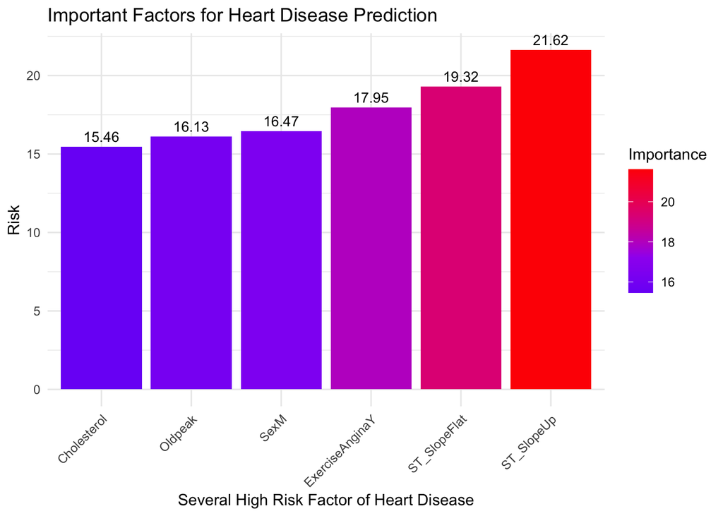

```r
# Only look at the top high importance factor
var_importance_high <- data.frame(
  Variable = c("SexM", "Cholesterol", "ExerciseAnginaY", "Oldpeak", "ST_SlopeFlat", "ST_SlopeUp"),
  Importance = c(16.474281, 15.459420, 17.950264, 16.130702, 19.315449, 21.616619)
)

# Create a bar chart of important variables
important_variables_high_plot <- ggplot(var_importance_high, aes(x = reorder(Variable, Importance), y = Importance, fill = Importance)) +
  geom_bar(stat = "identity") +
  scale_fill_gradient2(low = "blue", mid = "purple", high = "red", midpoint = median(var_importance_high$Importance)) +
  theme_minimal() +
  theme(axis.text.x = element_text(angle = 45, hjust = 1)) +
  xlab("Several High Risk Factor of Heart Disease") +
  ylab("Risk") +
  ggtitle("Important Factors for Heart Disease Prediction") +
  geom_text(aes(label = round(Importance, 2)), vjust = -0.5, size = 3.5)

# Show the plot
important_variables_high_plot
```

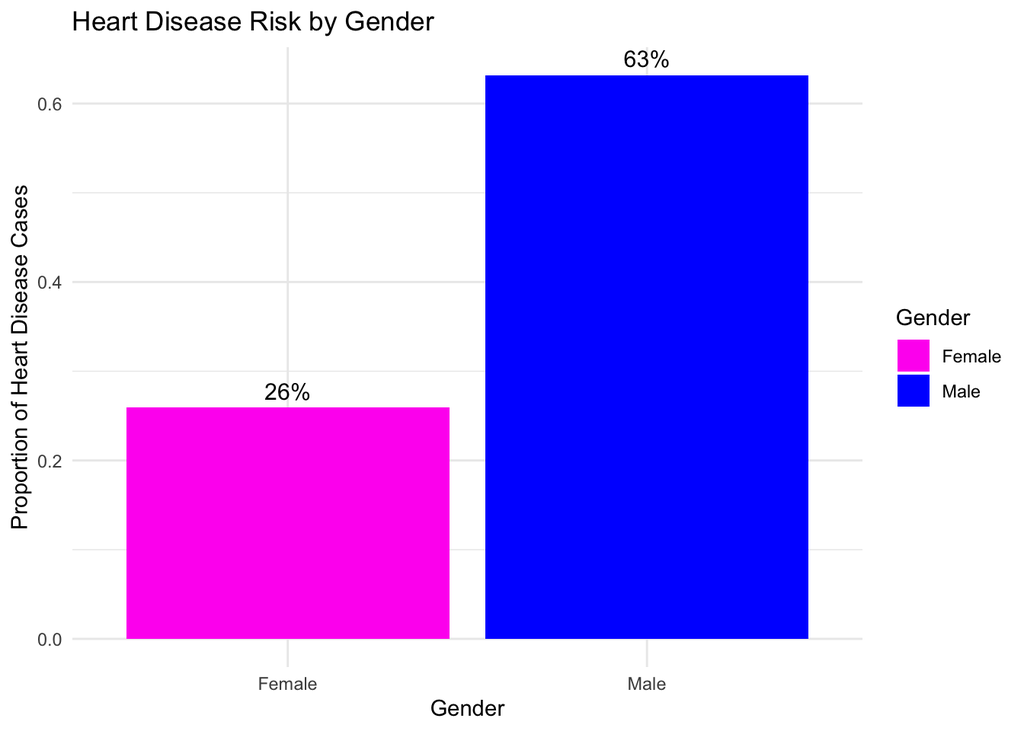

```r
# Calculate the proportion of heart disease cases for males and females
heart_disease_by_gender <- data %>%
  group_by(Sex, HeartDisease) %>%
  summarize(Count = n()) %>%
  mutate(Proportion = Count / sum(Count)) %>%
  filter(HeartDisease == 1)

# Load the necessary libraries
library(dplyr)
library(ggplot2)

# Create a bar plot of heart disease risk for males and females
gender_risk_plot <- ggplot(heart_disease_by_gender, aes(x = as.factor(Sex), y = Proportion, fill = as.factor(Sex))) +
  geom_bar(stat = "identity") +
  scale_fill_manual(values = c("#FF10F0", "blue"), labels = c("Female", "Male"), name = "Gender") +
  theme_minimal() +
  xlab("Gender") +
  ylab("Proportion of Heart Disease Cases") +
  ggtitle("Heart Disease Risk by Gender") +
  geom_text(aes(label = scales::percent(Proportion, accuracy = 1)), vjust = -0.5, size = 4) +
  scale_x_discrete(labels = c("Female", "Male"))

# Show the plot
gender_risk_plot
```

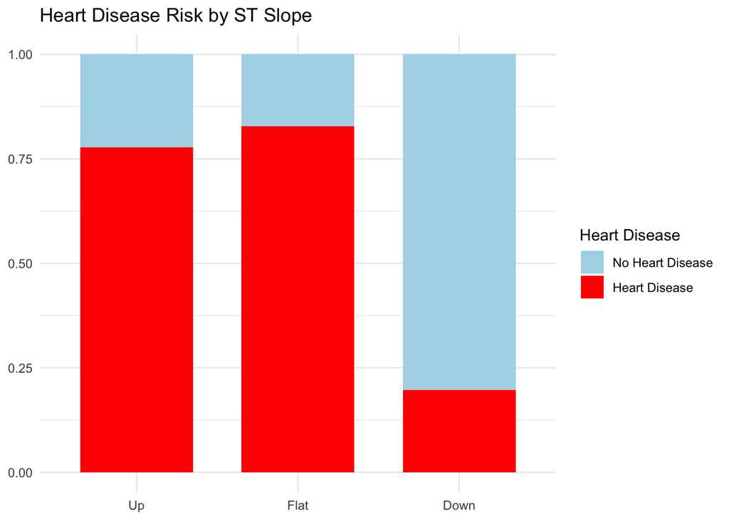

```r
# Calculate the proportion of heart disease cases for each ST_Slope category
heart_disease_by_st_slope <- data %>%
  group_by(ST_Slope, HeartDisease) %>%
  summarize(Count = n()) %>%
  mutate(Proportion = Count / sum(Count))

# Create a stacked bar plot of heart disease risk for different ST_Slope categories
st_slope_risk_stacked_bar_plot <- ggplot(heart_disease_by_st_slope, aes(x = as.factor(ST_Slope), y = Proportion, fill = as.factor(HeartDisease))) +
  geom_bar(stat = "identity", width = 0.7, position = "stack") +
  scale_fill_manual(values = c("lightblue", "red"), labels = c("No Heart Disease", "Heart Disease"), name = "Heart Disease") +
  theme_minimal() +
  theme(axis.title.x = element_blank(),
        axis.title.y = element_blank()) +
  ggtitle("Heart Disease Risk by ST Slope") +
  ylab("Proportion") +
  xlab("ST Slope") +
  scale_x_discrete(labels = c("Up", "Flat", "Down"))

# Display the plot
st_slope_risk_stacked_bar_plot
```

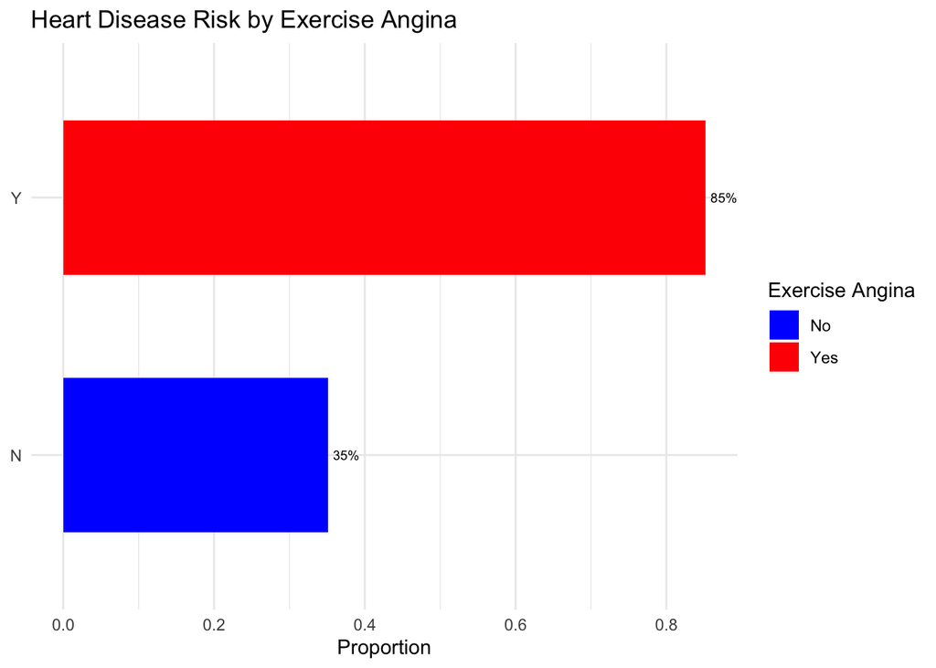

```r
# Calculate the proportion of heart disease cases for each ExerciseAngina category
heart_disease_by_exercise_angina <- data %>%
  group_by(ExerciseAngina, HeartDisease) %>%
  summarize(Count = n()) %>%
  mutate(Proportion = Count / sum(Count)) %>%
  filter(HeartDisease == 1)

# Create a horizontal bar plot of heart disease risk for different ExerciseAngina categories
exercise_angina_risk_plot <- ggplot(heart_disease_by_exercise_angina, aes(x = as.factor(ExerciseAngina), y = Proportion, fill = as.factor(ExerciseAngina))) +
  geom_bar(stat = "identity", width = 0.6, position = "dodge") +
  coord_flip() +
  scale_fill_manual(values = c("blue", "red"), labels = c("No", "Yes"), name = "Exercise Angina") +
  theme_minimal() +
  theme(axis.title.y = element_blank(),
        axis.ticks.y = element_blank()) +
  labs(x = "Exercise Angina", y = "Proportion", title = "Heart Disease Risk by Exercise Angina") +
  geom_text(aes(label = scales::percent(Proportion, accuracy = 1), y = Proportion), hjust = -0.2, size = 2.5)

# Show the plot
exercise_angina_risk_plot
```

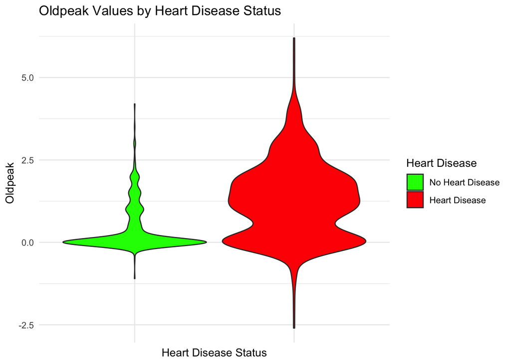

```r
# Create a violin plot of Oldpeak values for heart disease and non-heart disease cases
oldpeak_violin_plot <- ggplot(data, aes(x = as.factor(HeartDisease), y = Oldpeak, fill = as.factor(HeartDisease))) +
  geom_violin(scale = "width", trim = TRUE) +
  scale_fill_manual(values = c("green", "red"), labels = c("No Heart Disease", "Heart Disease"), name = "Heart Disease") +
  theme_minimal() +
  ggtitle("Oldpeak Values by Heart Disease Status") +
  ylab("Oldpeak") +
  xlab("Heart Disease Status") +
  theme(axis.text.x = element_blank(),
        axis.ticks.x = element_blank())

# Display the plot
oldpeak_violin_plot
```

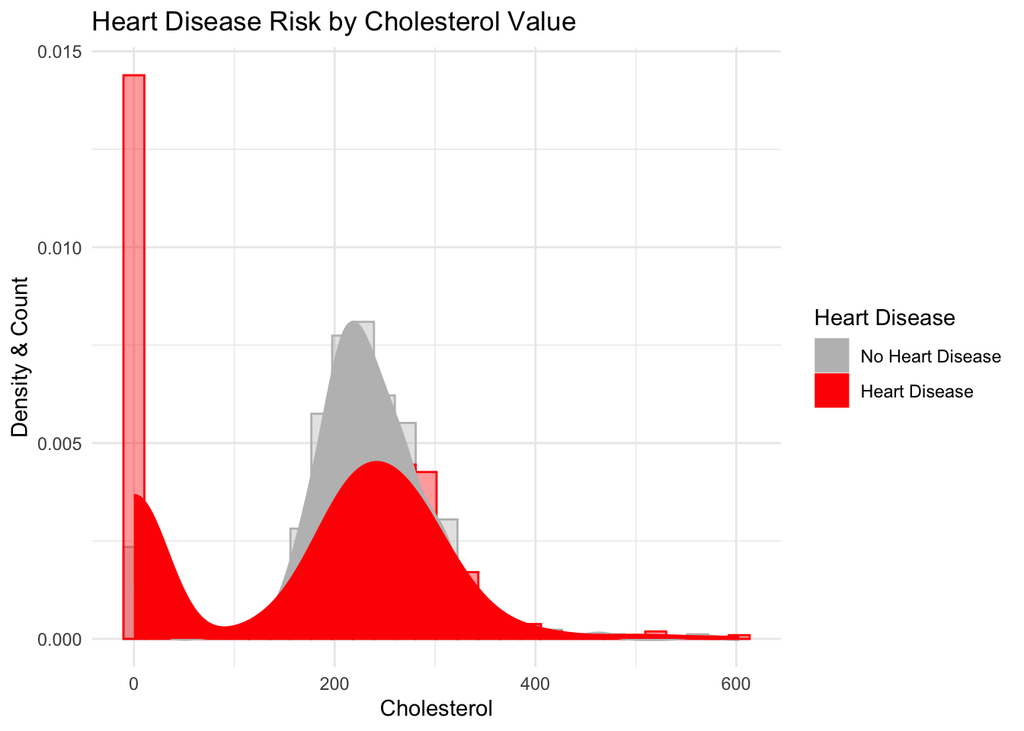

```r
# Create a histogram with a density plot overlay for heart disease risk and Cholesterol values
cholesterol_risk_plot <- ggplot(data, aes(x = Cholesterol, fill = HeartDisease, color = HeartDisease)) +
  geom_histogram(aes(y = ..density..), position = "identity", alpha = 0.4, bins = 30) +
  geom_density(size = 1) +
  theme_minimal() +
  labs(x = "Cholesterol", y = "Density & Count", title = "Heart Disease Risk by Cholesterol Value") +
  scale_fill_manual(values = c("grey", "red"), labels = c("No Heart Disease", "Heart Disease"), name = "Heart Disease") +
  scale_color_manual(values = c("grey", "red"), labels = c("No Heart Disease", "Heart Disease"), name = "Heart Disease")

# Show the plot
cholesterol_risk_plot
```

```r
# Save the plots as PNG file
ggsave("gender_risk_plot.png", plot = gender_risk_plot, width = 16, height = 10, dpi = 300)
ggsave("st_slope_risk_stacked_bar_plot.png", plot = st_slope_risk_stacked_bar_plot, width = 16, height = 10, dpi = 300)
ggsave("exercise_angina_risk_plot.png", plot = exercise_angina_risk_plot, width = 16, height = 10, dpi = 300)
ggsave("oldpeak_violin_plot.png", plot = oldpeak_violin_plot, width = 16, height = 10, dpi = 300)
ggsave("cholesterol_risk_plot.png", plot = cholesterol_risk_plot, width = 16, height = 10, dpi = 300)
```